# تخمین قیمت خانه

## ملیکا مرافق 810197581

# مقدمه

در این پروژه قصد داریم با استفاده از روشهای یادگیری ماشین قیمت خانه ها را با ویژگی های داده شده پیش بینی کنیم.

# توضیح پروژه

این پروژه شامل 4 فاز است.در فاز 0 به تجزیه و تحلیل داده های آموزشی می پردازیم. در فاز 1 پیش پردازش بر روی داده ها انجام می دهیم.در فاز دوم با استفاده مدل را آموزش می دهیم و آنها را بهینه سازی می کنیم و به بررسی تاثیر پیش پردازش بر نحوه ی عملکرد می پردازیم و در نهایت در فاز سوم به پیاده سازی روش های یادگیری جمعی می پردازیم.

```python
from sklearn.neighbors import KNeighborsRegressor
from sklearn.linear_model import LinearRegression
from sklearn.tree import DecisionTreeRegressor

from sklearn.ensemble import RandomForestRegressor
from sklearn.ensemble import VotingRegressor

from sklearn.model_selection import train_test_split
from sklearn.preprocessing import StandardScaler
from sklearn.model_selection import GridSearchCV
from sklearn.metrics import mean_squared_error, mean_absolute_error

from sklearn.model_selection import learning_curve

from  scipy.stats import norm
import matplotlib.pyplot as plt
import numpy as np
import pandas as pd
import seaborn as sns
import math

train = pd.read_csv ('D:/هوش/CA/4/train.csv')
train
```

|  | Id | MSSubClass | MSZoning | LotFrontage | LotArea | Street | Alley | LotShape | LandContour | Utilities | ... | PoolArea | PoolQC | Fence | MiscFeature | MiscVal | MoSold | YrSold | SaleType | SaleCondition | SalePrice |
| --- | --- | --- | --- | --- | --- | --- | --- | --- | --- | --- | --- | --- | --- | --- | --- | --- | --- | --- | --- | --- | --- |
| 0 | 1 | 60 | RL | 65.0 | 8450 | Pave | NaN | Reg | Lvl | AllPub | ... | 0 | NaN | NaN | NaN | 0 | 2 | 2008 | WD | Normal | 208500 |
| 1 | 2 | 20 | RL | 80.0 | 9600 | Pave | NaN | Reg | Lvl | AllPub | ... | 0 | NaN | NaN | NaN | 0 | 5 | 2007 | WD | Normal | 181500 |
| 2 | 3 | 60 | RL | 68.0 | 11250 | Pave | NaN | IR1 | Lvl | AllPub | ... | 0 | NaN | NaN | NaN | 0 | 9 | 2008 | WD | Normal | 223500 |
| 3 | 4 | 70 | RL | 60.0 | 9550 | Pave | NaN | IR1 | Lvl | AllPub | ... | 0 | NaN | NaN | NaN | 0 | 2 | 2006 | WD | Abnorml | 140000 |
| 4 | 5 | 60 | RL | 84.0 | 14260 | Pave | NaN | IR1 | Lvl | AllPub | ... | 0 | NaN | NaN | NaN | 0 | 12 | 2008 | WD | Normal | 250000 |
| 5 | 6 | 50 | RL | 85.0 | 14115 | Pave | NaN | IR1 | Lvl | AllPub | ... | 0 | NaN | MnPrv | Shed | 700 | 10 | 2009 | WD | Normal | 143000 |
| 6 | 7 | 20 | RL | 75.0 | 10084 | Pave | NaN | Reg | Lvl | AllPub | ... | 0 | NaN | NaN | NaN | 0 | 8 | 2007 | WD | Normal | 307000 |
| 7 | 8 | 60 | RL | NaN | 10382 | Pave | NaN | IR1 | Lvl | AllPub | ... | 0 | NaN | NaN | Shed | 350 | 11 | 2009 | WD | Normal | 200000 |
| 8 | 9 | 50 | RM | 51.0 | 6120 | Pave | NaN | Reg | Lvl | AllPub | ... | 0 | NaN | NaN | NaN | 0 | 4 | 2008 | WD | Abnorml | 129900 |
| 9 | 10 | 190 | RL | 50.0 | 7420 | Pave | NaN | Reg | Lvl | AllPub | ... | 0 | NaN | NaN | NaN | 0 | 1 | 2008 | WD | Normal | 118000 |
| 10 | 11 | 20 | RL | 70.0 | 11200 | Pave | NaN | Reg | Lvl | AllPub | ... | 0 | NaN | NaN | NaN | 0 | 2 | 2008 | WD | Normal | 129500 |
| 11 | 12 | 60 | RL | 85.0 | 11924 | Pave | NaN | IR1 | Lvl | AllPub | ... | 0 | NaN | NaN | NaN | 0 | 7 | 2006 | New | Partial | 345000 |
| 12 | 13 | 20 | RL | NaN | 12968 | Pave | NaN | IR2 | Lvl | AllPub | ... | 0 | NaN | NaN | NaN | 0 | 9 | 2008 | WD | Normal | 144000 |
| 13 | 14 | 20 | RL | 91.0 | 10652 | Pave | NaN | IR1 | Lvl | AllPub | ... | 0 | NaN | NaN | NaN | 0 | 8 | 2007 | New | Partial | 279500 |
| 14 | 15 | 20 | RL | NaN | 10920 | Pave | NaN | IR1 | Lvl | AllPub | ... | 0 | NaN | GdWo | NaN | 0 | 5 | 2008 | WD | Normal | 157000 |
| 15 | 16 | 45 | RM | 51.0 | 6120 | Pave | NaN | Reg | Lvl | AllPub | ... | 0 | NaN | GdPrv | NaN | 0 | 7 | 2007 | WD | Normal | 132000 |
| 16 | 17 | 20 | RL | NaN | 11241 | Pave | NaN | IR1 | Lvl | AllPub | ... | 0 | NaN | NaN | Shed | 700 | 3 | 2010 | WD | Normal | 149000 |
| 17 | 18 | 90 | RL | 72.0 | 10791 | Pave | NaN | Reg | Lvl | AllPub | ... | 0 | NaN | NaN | Shed | 500 | 10 | 2006 | WD | Normal | 90000 |
| 18 | 19 | 20 | RL | 66.0 | 13695 | Pave | NaN | Reg | Lvl | AllPub | ... | 0 | NaN | NaN | NaN | 0 | 6 | 2008 | WD | Normal | 159000 |
| 19 | 20 | 20 | RL | 70.0 | 7560 | Pave | NaN | Reg | Lvl | AllPub | ... | 0 | NaN | MnPrv | NaN | 0 | 5 | 2009 | COD | Abnorml | 139000 |
| 20 | 21 | 60 | RL | 101.0 | 14215 | Pave | NaN | IR1 | Lvl | AllPub | ... | 0 | NaN | NaN | NaN | 0 | 11 | 2006 | New | Partial | 325300 |
| 21 | 22 | 45 | RM | 57.0 | 7449 | Pave | Grvl | Reg | Bnk | AllPub | ... | 0 | NaN | GdPrv | NaN | 0 | 6 | 2007 | WD | Normal | 139400 |
| 22 | 23 | 20 | RL | 75.0 | 9742 | Pave | NaN | Reg | Lvl | AllPub | ... | 0 | NaN | NaN | NaN | 0 | 9 | 2008 | WD | Normal | 230000 |
| 23 | 24 | 120 | RM | 44.0 | 4224 | Pave | NaN | Reg | Lvl | AllPub | ... | 0 | NaN | NaN | NaN | 0 | 6 | 2007 | WD | Normal | 129900 |
| 24 | 25 | 20 | RL | NaN | 8246 | Pave | NaN | IR1 | Lvl | AllPub | ... | 0 | NaN | MnPrv | NaN | 0 | 5 | 2010 | WD | Normal | 154000 |
| 25 | 26 | 20 | RL | 110.0 | 14230 | Pave | NaN | Reg | Lvl | AllPub | ... | 0 | NaN | NaN | NaN | 0 | 7 | 2009 | WD | Normal | 256300 |
| 26 | 27 | 20 | RL | 60.0 | 7200 | Pave | NaN | Reg | Lvl | AllPub | ... | 0 | NaN | NaN | NaN | 0 | 5 | 2010 | WD | Normal | 134800 |
| 27 | 28 | 20 | RL | 98.0 | 11478 | Pave | NaN | Reg | Lvl | AllPub | ... | 0 | NaN | NaN | NaN | 0 | 5 | 2010 | WD | Normal | 306000 |
| 28 | 29 | 20 | RL | 47.0 | 16321 | Pave | NaN | IR1 | Lvl | AllPub | ... | 0 | NaN | NaN | NaN | 0 | 12 | 2006 | WD | Normal | 207500 |
| 29 | 30 | 30 | RM | 60.0 | 6324 | Pave | NaN | IR1 | Lvl | AllPub | ... | 0 | NaN | NaN | NaN | 0 | 5 | 2008 | WD | Normal | 68500 |
| ... | ... | ... | ... | ... | ... | ... | ... | ... | ... | ... | ... | ... | ... | ... | ... | ... | ... | ... | ... | ... | ... |
| 1430 | 1431 | 60 | RL | 60.0 | 21930 | Pave | NaN | IR3 | Lvl | AllPub | ... | 0 | NaN | NaN | NaN | 0 | 7 | 2006 | WD | Normal | 192140 |
| 1431 | 1432 | 120 | RL | NaN | 4928 | Pave | NaN | IR1 | Lvl | AllPub | ... | 0 | NaN | NaN | NaN | 0 | 10 | 2009 | WD | Normal | 143750 |
| 1432 | 1433 | 30 | RL | 60.0 | 10800 | Pave | Grvl | Reg | Lvl | AllPub | ... | 0 | NaN | NaN | NaN | 0 | 8 | 2007 | WD | Normal | 64500 |
| 1433 | 1434 | 60 | RL | 93.0 | 10261 | Pave | NaN | IR1 | Lvl | AllPub | ... | 0 | NaN | NaN | NaN | 0 | 5 | 2008 | WD | Normal | 186500 |
| 1434 | 1435 | 20 | RL | 80.0 | 17400 | Pave | NaN | Reg | Low | AllPub | ... | 0 | NaN | NaN | NaN | 0 | 5 | 2006 | WD | Normal | 160000 |
| 1435 | 1436 | 20 | RL | 80.0 | 8400 | Pave | NaN | Reg | Lvl | AllPub | ... | 0 | NaN | GdPrv | NaN | 0 | 7 | 2008 | COD | Abnorml | 174000 |
| 1436 | 1437 | 20 | RL | 60.0 | 9000 | Pave | NaN | Reg | Lvl | AllPub | ... | 0 | NaN | GdWo | NaN | 0 | 5 | 2007 | WD | Normal | 120500 |
| 1437 | 1438 | 20 | RL | 96.0 | 12444 | Pave | NaN | Reg | Lvl | AllPub | ... | 0 | NaN | NaN | NaN | 0 | 11 | 2008 | New | Partial | 394617 |
| 1438 | 1439 | 20 | RM | 90.0 | 7407 | Pave | NaN | Reg | Lvl | AllPub | ... | 0 | NaN | MnPrv | NaN | 0 | 4 | 2010 | WD | Normal | 149700 |
| 1439 | 1440 | 60 | RL | 80.0 | 11584 | Pave | NaN | Reg | Lvl | AllPub | ... | 0 | NaN | NaN | NaN | 0 | 11 | 2007 | WD | Normal | 197000 |
| 1440 | 1441 | 70 | RL | 79.0 | 11526 | Pave | NaN | IR1 | Bnk | AllPub | ... | 0 | NaN | NaN | NaN | 0 | 9 | 2008 | WD | Normal | 191000 |
| 1441 | 1442 | 120 | RM | NaN | 4426 | Pave | NaN | Reg | Lvl | AllPub | ... | 0 | NaN | NaN | NaN | 0 | 5 | 2008 | WD | Normal | 149300 |
| 1442 | 1443 | 60 | FV | 85.0 | 11003 | Pave | NaN | Reg | Lvl | AllPub | ... | 0 | NaN | NaN | NaN | 0 | 4 | 2009 | WD | Normal | 310000 |
| 1443 | 1444 | 30 | RL | NaN | 8854 | Pave | NaN | Reg | Lvl | AllPub | ... | 0 | NaN | NaN | NaN | 0 | 5 | 2009 | WD | Normal | 121000 |
| 1444 | 1445 | 20 | RL | 63.0 | 8500 | Pave | NaN | Reg | Lvl | AllPub | ... | 0 | NaN | NaN | NaN | 0 | 11 | 2007 | WD | Normal | 179600 |
| 1445 | 1446 | 85 | RL | 70.0 | 8400 | Pave | NaN | Reg | Lvl | AllPub | ... | 0 | NaN | NaN | NaN | 0 | 5 | 2007 | WD | Normal | 129000 |
| 1446 | 1447 | 20 | RL | NaN | 26142 | Pave | NaN | IR1 | Lvl | AllPub | ... | 0 | NaN | NaN | NaN | 0 | 4 | 2010 | WD | Normal | 157900 |
| 1447 | 1448 | 60 | RL | 80.0 | 10000 | Pave | NaN | Reg | Lvl | AllPub | ... | 0 | NaN | NaN | NaN | 0 | 12 | 2007 | WD | Normal | 240000 |
| 1448 | 1449 | 50 | RL | 70.0 | 11767 | Pave | NaN | Reg | Lvl | AllPub | ... | 0 | NaN | GdWo | NaN | 0 | 5 | 2007 | WD | Normal | 112000 |
| 1449 | 1450 | 180 | RM | 21.0 | 1533 | Pave | NaN | Reg | Lvl | AllPub | ... | 0 | NaN | NaN | NaN | 0 | 8 | 2006 | WD | Abnorml | 92000 |
| 1450 | 1451 | 90 | RL | 60.0 | 9000 | Pave | NaN | Reg | Lvl | AllPub | ... | 0 | NaN | NaN | NaN | 0 | 9 | 2009 | WD | Normal | 136000 |
| 1451 | 1452 | 20 | RL | 78.0 | 9262 | Pave | NaN | Reg | Lvl | AllPub | ... | 0 | NaN | NaN | NaN | 0 | 5 | 2009 | New | Partial | 287090 |
| 1452 | 1453 | 180 | RM | 35.0 | 3675 | Pave | NaN | Reg | Lvl | AllPub | ... | 0 | NaN | NaN | NaN | 0 | 5 | 2006 | WD | Normal | 145000 |
| 1453 | 1454 | 20 | RL | 90.0 | 17217 | Pave | NaN | Reg | Lvl | AllPub | ... | 0 | NaN | NaN | NaN | 0 | 7 | 2006 | WD | Abnorml | 84500 |
| 1454 | 1455 | 20 | FV | 62.0 | 7500 | Pave | Pave | Reg | Lvl | AllPub | ... | 0 | NaN | NaN | NaN | 0 | 10 | 2009 | WD | Normal | 185000 |
| 1455 | 1456 | 60 | RL | 62.0 | 7917 | Pave | NaN | Reg | Lvl | AllPub | ... | 0 | NaN | NaN | NaN | 0 | 8 | 2007 | WD | Normal | 175000 |
| 1456 | 1457 | 20 | RL | 85.0 | 13175 | Pave | NaN | Reg | Lvl | AllPub | ... | 0 | NaN | MnPrv | NaN | 0 | 2 | 2010 | WD | Normal | 210000 |
| 1457 | 1458 | 70 | RL | 66.0 | 9042 | Pave | NaN | Reg | Lvl | AllPub | ... | 0 | NaN | GdPrv | Shed | 2500 | 5 | 2010 | WD | Normal | 266500 |
| 1458 | 1459 | 20 | RL | 68.0 | 9717 | Pave | NaN | Reg | Lvl | AllPub | ... | 0 | NaN | NaN | NaN | 0 | 4 | 2010 | WD | Normal | 142125 |
| 1459 | 1460 | 20 | RL | 75.0 | 9937 | Pave | NaN | Reg | Lvl | AllPub | ... | 0 | NaN | NaN | NaN | 0 | 6 | 2008 | WD | Normal | 147500 |

1460 rows × 81 columns

## Phase 0

## 1

```python
train.describe(include ='all')
```

|  | Id | MSSubClass | MSZoning | LotFrontage | LotArea | Street | Alley | LotShape | LandContour | Utilities | ... | PoolArea | PoolQC | Fence | MiscFeature | MiscVal | MoSold | YrSold | SaleType | SaleCondition | SalePrice |
| --- | --- | --- | --- | --- | --- | --- | --- | --- | --- | --- | --- | --- | --- | --- | --- | --- | --- | --- | --- | --- | --- |
| count | 1460.000000 | 1460.000000 | 1460 | 1201.000000 | 1460.000000 | 1460 | 91 | 1460 | 1460 | 1460 | ... | 1460.000000 | 7 | 281 | 54 | 1460.000000 | 1460.000000 | 1460.000000 | 1460 | 1460 | 1460.000000 |
| unique | NaN | NaN | 5 | NaN | NaN | 2 | 2 | 4 | 4 | 2 | ... | NaN | 3 | 4 | 4 | NaN | NaN | NaN | 9 | 6 | NaN |
| top | NaN | NaN | RL | NaN | NaN | Pave | Grvl | Reg | Lvl | AllPub | ... | NaN | Gd | MnPrv | Shed | NaN | NaN | NaN | WD | Normal | NaN |
| freq | NaN | NaN | 1151 | NaN | NaN | 1454 | 50 | 925 | 1311 | 1459 | ... | NaN | 3 | 157 | 49 | NaN | NaN | NaN | 1267 | 1198 | NaN |
| mean | 730.500000 | 56.897260 | NaN | 70.049958 | 10516.828082 | NaN | NaN | NaN | NaN | NaN | ... | 2.758904 | NaN | NaN | NaN | 43.489041 | 6.321918 | 2007.815753 | NaN | NaN | 180921.195890 |
| std | 421.610009 | 42.300571 | NaN | 24.284752 | 9981.264932 | NaN | NaN | NaN | NaN | NaN | ... | 40.177307 | NaN | NaN | NaN | 496.123024 | 2.703626 | 1.328095 | NaN | NaN | 79442.502883 |
| min | 1.000000 | 20.000000 | NaN | 21.000000 | 1300.000000 | NaN | NaN | NaN | NaN | NaN | ... | 0.000000 | NaN | NaN | NaN | 0.000000 | 1.000000 | 2006.000000 | NaN | NaN | 34900.000000 |
| 25% | 365.750000 | 20.000000 | NaN | 59.000000 | 7553.500000 | NaN | NaN | NaN | NaN | NaN | ... | 0.000000 | NaN | NaN | NaN | 0.000000 | 5.000000 | 2007.000000 | NaN | NaN | 129975.000000 |
| 50% | 730.500000 | 50.000000 | NaN | 69.000000 | 9478.500000 | NaN | NaN | NaN | NaN | NaN | ... | 0.000000 | NaN | NaN | NaN | 0.000000 | 6.000000 | 2008.000000 | NaN | NaN | 163000.000000 |
| 75% | 1095.250000 | 70.000000 | NaN | 80.000000 | 11601.500000 | NaN | NaN | NaN | NaN | NaN | ... | 0.000000 | NaN | NaN | NaN | 0.000000 | 8.000000 | 2009.000000 | NaN | NaN | 214000.000000 |
| max | 1460.000000 | 190.000000 | NaN | 313.000000 | 215245.000000 | NaN | NaN | NaN | NaN | NaN | ... | 738.000000 | NaN | NaN | NaN | 15500.000000 | 12.000000 | 2010.000000 | NaN | NaN | 755000.000000 |

11 rows × 81 columns

```python
train.info()
```

```
<class 'pandas.core.frame.DataFrame'>
RangeIndex: 1460 entries, 0 to 1459
Data columns (total 81 columns):
Id               1460 non-null int64
MSSubClass       1460 non-null int64
MSZoning         1460 non-null object
LotFrontage      1201 non-null float64
LotArea          1460 non-null int64
Street           1460 non-null object
Alley            91 non-null object
LotShape         1460 non-null object
LandContour      1460 non-null object
Utilities        1460 non-null object
LotConfig        1460 non-null object
LandSlope        1460 non-null object
Neighborhood     1460 non-null object
Condition1       1460 non-null object
Condition2       1460 non-null object
BldgType         1460 non-null object
HouseStyle       1460 non-null object
OverallQual      1460 non-null int64
OverallCond      1460 non-null int64
YearBuilt        1460 non-null int64
YearRemodAdd     1460 non-null int64
RoofStyle        1460 non-null object
RoofMatl         1460 non-null object
Exterior1st      1460 non-null object
Exterior2nd      1460 non-null object
MasVnrType       1452 non-null object
MasVnrArea       1452 non-null float64
ExterQual        1460 non-null object
ExterCond        1460 non-null object
Foundation       1460 non-null object
BsmtQual         1423 non-null object
BsmtCond         1423 non-null object
BsmtExposure     1422 non-null object
BsmtFinType1     1423 non-null object
BsmtFinSF1       1460 non-null int64
BsmtFinType2     1422 non-null object
BsmtFinSF2       1460 non-null int64
```

[output cut: 31 more lines]

```
EnclosedPorch    1460 non-null int64
3SsnPorch        1460 non-null int64
ScreenPorch      1460 non-null int64
PoolArea         1460 non-null int64
PoolQC           7 non-null object
Fence            281 non-null object
MiscFeature      54 non-null object
MiscVal          1460 non-null int64
MoSold           1460 non-null int64
YrSold           1460 non-null int64
SaleType         1460 non-null object
SaleCondition    1460 non-null object
SalePrice        1460 non-null int64
dtypes: float64(3), int64(35), object(43)
memory usage: 924.0+ KB
```

## 2

### درصد داده های از دست رفته

```python
m = train.isna().sum()/train.shape[0] * 100
m.sort_values(ascending = False)
```

```
PoolQC           99.520548
MiscFeature      96.301370
Alley            93.767123
Fence            80.753425
FireplaceQu      47.260274
LotFrontage      17.739726
GarageCond        5.547945
GarageType        5.547945
GarageYrBlt       5.547945
GarageFinish      5.547945
GarageQual        5.547945
BsmtExposure      2.602740
BsmtFinType2      2.602740
BsmtFinType1      2.534247
BsmtCond          2.534247
BsmtQual          2.534247
MasVnrArea        0.547945
MasVnrType        0.547945
Electrical        0.068493
Utilities         0.000000
YearRemodAdd      0.000000
MSSubClass        0.000000
Foundation        0.000000
ExterCond         0.000000
ExterQual         0.000000
Exterior2nd       0.000000
Exterior1st       0.000000
RoofMatl          0.000000
RoofStyle         0.000000
YearBuilt         0.000000
                   ...
GarageArea        0.000000
PavedDrive        0.000000
WoodDeckSF        0.000000
OpenPorchSF       0.000000
3SsnPorch         0.000000
BsmtUnfSF         0.000000
ScreenPorch       0.000000
PoolArea          0.000000
MiscVal           0.000000
MoSold            0.000000
YrSold            0.000000
SaleType          0.000000
Functional        0.000000
TotRmsAbvGrd      0.000000
KitchenQual       0.000000
KitchenAbvGr      0.000000
BedroomAbvGr      0.000000
HalfBath          0.000000
FullBath          0.000000
BsmtHalfBath      0.000000
BsmtFullBath      0.000000
GrLivArea         0.000000
LowQualFinSF      0.000000
2ndFlrSF          0.000000
1stFlrSF          0.000000
CentralAir        0.000000
SaleCondition     0.000000
Heating           0.000000
TotalBsmtSF       0.000000
Id                0.000000
Length: 81, dtype: float64
```

## 3

### Heatmap

OverallQuality , GrLivArea , GarageCars , GarageArea , TotalBsmtSF,YearBuilt

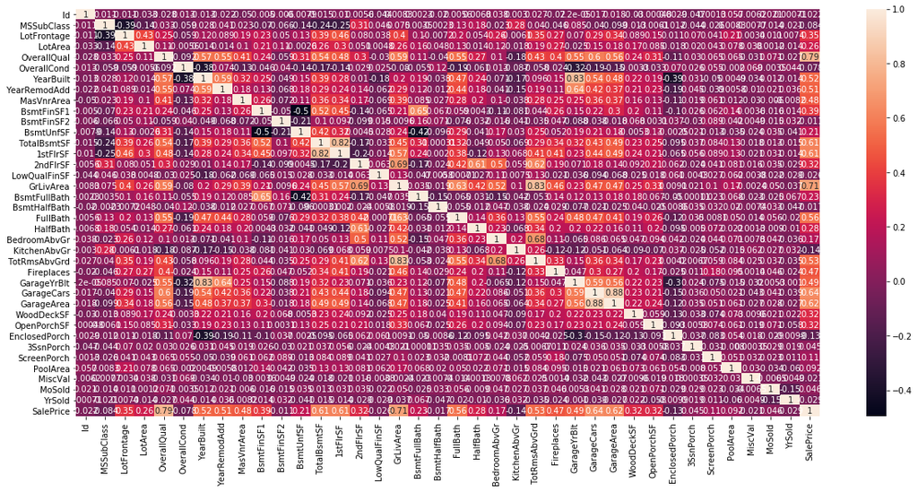

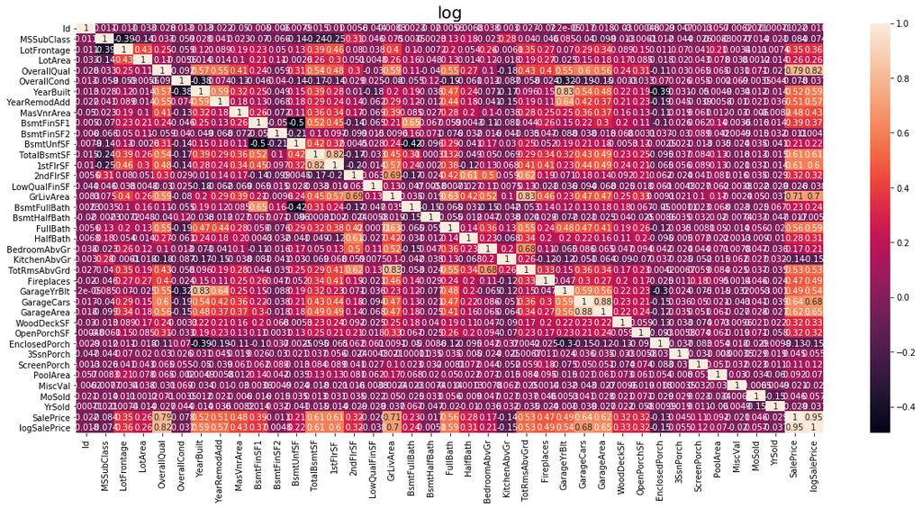

```python
plt.figure(figsize=(20,9))
corr1 = train.corr()

train["logSalePrice"] = np.log(train["SalePrice"])
corr2 = train.corr()

sns.heatmap(corr1 ,annot=True)
plt.show()
plt.figure(figsize=(20,9))
sns.heatmap(corr2,annot=True)

plt.title('log',fontsize = 20)
plt.show()
```

## 4 بسته به متد دارد( برای مثال در kendall تغییر نمی کند) .در Pearson's correlation coefficient که ضریب وابستگی خطی اندازه گیری می شود، یک خط راست در نمودار پراکندگی(scatter plot) گذرانده و شیب آن را محاسبه می کند. واضح است که با گرفتن لگاریتم شیب خط تفاوت می کند. SalePrice نسبت به توزیع نرمال انحراف دارد با گرفتن لگاریتم به توزیع نرمال نزدیک تر می شود.

## 5

وابستگی داده های دسته ای به قیمت خانه را نمی توان نشان داد(تنها برای داده های عددی است)

## 6

### scatter / Hexbin

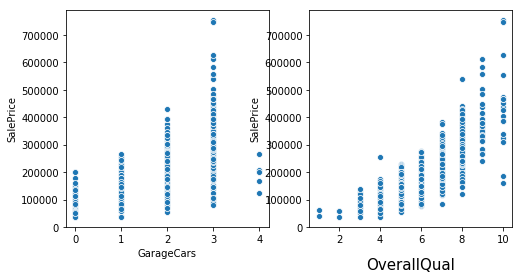

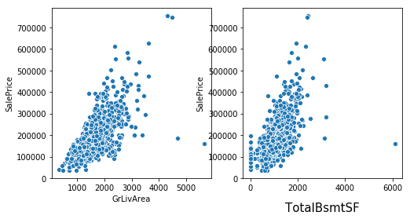

```python
fig, axs = plt.subplots(1,2,figsize = (8,4))

sns.scatterplot(x = train["GarageCars"],y = train["SalePrice"],ax = axs[0])
plt.xlabel('Garage Cars', size=15,labelpad=12.5)

sns.scatterplot(x = train['OverallQual'],y = train['SalePrice'],ax = axs[1])
plt.xlabel('OverallQual', size=15,labelpad=12.5)

plt.show()

fig, ax = plt.subplots(1,2,figsize = (8,4))

sns.scatterplot(x = train["GrLivArea"],y=train["SalePrice"],ax=ax[0])
plt.xlabel('GrLive Area', size=15,labelpad=12.5)

sns.scatterplot(x = train["TotalBsmtSF"],y=train["SalePrice"],ax=ax[1])
plt.xlabel('TotalBsmtSF', size=15,labelpad=12.5)

plt.show()
```

## 8

```python
# Remove outliers
train.drop(train[(train['GrLivArea']>4500) & (train['SalePrice']<250000)].index, inplace=True)
train.reset_index(drop=True, inplace=True)

train = train.drop("Id",axis = 1)
train
```

|  | MSSubClass | MSZoning | LotFrontage | LotArea | Street | Alley | LotShape | LandContour | Utilities | LotConfig | ... | PoolQC | Fence | MiscFeature | MiscVal | MoSold | YrSold | SaleType | SaleCondition | SalePrice | logSalePrice |
| --- | --- | --- | --- | --- | --- | --- | --- | --- | --- | --- | --- | --- | --- | --- | --- | --- | --- | --- | --- | --- | --- |
| 0 | 60 | RL | 65.0 | 8450 | Pave | NaN | Reg | Lvl | AllPub | Inside | ... | NaN | NaN | NaN | 0 | 2 | 2008 | WD | Normal | 208500 | 12.247694 |
| 1 | 20 | RL | 80.0 | 9600 | Pave | NaN | Reg | Lvl | AllPub | FR2 | ... | NaN | NaN | NaN | 0 | 5 | 2007 | WD | Normal | 181500 | 12.109011 |
| 2 | 60 | RL | 68.0 | 11250 | Pave | NaN | IR1 | Lvl | AllPub | Inside | ... | NaN | NaN | NaN | 0 | 9 | 2008 | WD | Normal | 223500 | 12.317167 |
| 3 | 70 | RL | 60.0 | 9550 | Pave | NaN | IR1 | Lvl | AllPub | Corner | ... | NaN | NaN | NaN | 0 | 2 | 2006 | WD | Abnorml | 140000 | 11.849398 |
| 4 | 60 | RL | 84.0 | 14260 | Pave | NaN | IR1 | Lvl | AllPub | FR2 | ... | NaN | NaN | NaN | 0 | 12 | 2008 | WD | Normal | 250000 | 12.429216 |
| 5 | 50 | RL | 85.0 | 14115 | Pave | NaN | IR1 | Lvl | AllPub | Inside | ... | NaN | MnPrv | Shed | 700 | 10 | 2009 | WD | Normal | 143000 | 11.870600 |
| 6 | 20 | RL | 75.0 | 10084 | Pave | NaN | Reg | Lvl | AllPub | Inside | ... | NaN | NaN | NaN | 0 | 8 | 2007 | WD | Normal | 307000 | 12.634603 |
| 7 | 60 | RL | NaN | 10382 | Pave | NaN | IR1 | Lvl | AllPub | Corner | ... | NaN | NaN | Shed | 350 | 11 | 2009 | WD | Normal | 200000 | 12.206073 |
| 8 | 50 | RM | 51.0 | 6120 | Pave | NaN | Reg | Lvl | AllPub | Inside | ... | NaN | NaN | NaN | 0 | 4 | 2008 | WD | Abnorml | 129900 | 11.774520 |
| 9 | 190 | RL | 50.0 | 7420 | Pave | NaN | Reg | Lvl | AllPub | Corner | ... | NaN | NaN | NaN | 0 | 1 | 2008 | WD | Normal | 118000 | 11.678440 |
| 10 | 20 | RL | 70.0 | 11200 | Pave | NaN | Reg | Lvl | AllPub | Inside | ... | NaN | NaN | NaN | 0 | 2 | 2008 | WD | Normal | 129500 | 11.771436 |
| 11 | 60 | RL | 85.0 | 11924 | Pave | NaN | IR1 | Lvl | AllPub | Inside | ... | NaN | NaN | NaN | 0 | 7 | 2006 | New | Partial | 345000 | 12.751300 |
| 12 | 20 | RL | NaN | 12968 | Pave | NaN | IR2 | Lvl | AllPub | Inside | ... | NaN | NaN | NaN | 0 | 9 | 2008 | WD | Normal | 144000 | 11.877569 |
| 13 | 20 | RL | 91.0 | 10652 | Pave | NaN | IR1 | Lvl | AllPub | Inside | ... | NaN | NaN | NaN | 0 | 8 | 2007 | New | Partial | 279500 | 12.540758 |
| 14 | 20 | RL | NaN | 10920 | Pave | NaN | IR1 | Lvl | AllPub | Corner | ... | NaN | GdWo | NaN | 0 | 5 | 2008 | WD | Normal | 157000 | 11.964001 |
| 15 | 45 | RM | 51.0 | 6120 | Pave | NaN | Reg | Lvl | AllPub | Corner | ... | NaN | GdPrv | NaN | 0 | 7 | 2007 | WD | Normal | 132000 | 11.790557 |
| 16 | 20 | RL | NaN | 11241 | Pave | NaN | IR1 | Lvl | AllPub | CulDSac | ... | NaN | NaN | Shed | 700 | 3 | 2010 | WD | Normal | 149000 | 11.911702 |
| 17 | 90 | RL | 72.0 | 10791 | Pave | NaN | Reg | Lvl | AllPub | Inside | ... | NaN | NaN | Shed | 500 | 10 | 2006 | WD | Normal | 90000 | 11.407565 |
| 18 | 20 | RL | 66.0 | 13695 | Pave | NaN | Reg | Lvl | AllPub | Inside | ... | NaN | NaN | NaN | 0 | 6 | 2008 | WD | Normal | 159000 | 11.976659 |
| 19 | 20 | RL | 70.0 | 7560 | Pave | NaN | Reg | Lvl | AllPub | Inside | ... | NaN | MnPrv | NaN | 0 | 5 | 2009 | COD | Abnorml | 139000 | 11.842229 |
| 20 | 60 | RL | 101.0 | 14215 | Pave | NaN | IR1 | Lvl | AllPub | Corner | ... | NaN | NaN | NaN | 0 | 11 | 2006 | New | Partial | 325300 | 12.692503 |
| 21 | 45 | RM | 57.0 | 7449 | Pave | Grvl | Reg | Bnk | AllPub | Inside | ... | NaN | GdPrv | NaN | 0 | 6 | 2007 | WD | Normal | 139400 | 11.845103 |
| 22 | 20 | RL | 75.0 | 9742 | Pave | NaN | Reg | Lvl | AllPub | Inside | ... | NaN | NaN | NaN | 0 | 9 | 2008 | WD | Normal | 230000 | 12.345835 |
| 23 | 120 | RM | 44.0 | 4224 | Pave | NaN | Reg | Lvl | AllPub | Inside | ... | NaN | NaN | NaN | 0 | 6 | 2007 | WD | Normal | 129900 | 11.774520 |
| 24 | 20 | RL | NaN | 8246 | Pave | NaN | IR1 | Lvl | AllPub | Inside | ... | NaN | MnPrv | NaN | 0 | 5 | 2010 | WD | Normal | 154000 | 11.944708 |
| 25 | 20 | RL | 110.0 | 14230 | Pave | NaN | Reg | Lvl | AllPub | Corner | ... | NaN | NaN | NaN | 0 | 7 | 2009 | WD | Normal | 256300 | 12.454104 |
| 26 | 20 | RL | 60.0 | 7200 | Pave | NaN | Reg | Lvl | AllPub | Corner | ... | NaN | NaN | NaN | 0 | 5 | 2010 | WD | Normal | 134800 | 11.811547 |
| 27 | 20 | RL | 98.0 | 11478 | Pave | NaN | Reg | Lvl | AllPub | Inside | ... | NaN | NaN | NaN | 0 | 5 | 2010 | WD | Normal | 306000 | 12.631340 |
| 28 | 20 | RL | 47.0 | 16321 | Pave | NaN | IR1 | Lvl | AllPub | CulDSac | ... | NaN | NaN | NaN | 0 | 12 | 2006 | WD | Normal | 207500 | 12.242887 |
| 29 | 30 | RM | 60.0 | 6324 | Pave | NaN | IR1 | Lvl | AllPub | Inside | ... | NaN | NaN | NaN | 0 | 5 | 2008 | WD | Normal | 68500 | 11.134589 |
| ... | ... | ... | ... | ... | ... | ... | ... | ... | ... | ... | ... | ... | ... | ... | ... | ... | ... | ... | ... | ... | ... |
| 1428 | 60 | RL | 60.0 | 21930 | Pave | NaN | IR3 | Lvl | AllPub | Inside | ... | NaN | NaN | NaN | 0 | 7 | 2006 | WD | Normal | 192140 | 12.165980 |
| 1429 | 120 | RL | NaN | 4928 | Pave | NaN | IR1 | Lvl | AllPub | Inside | ... | NaN | NaN | NaN | 0 | 10 | 2009 | WD | Normal | 143750 | 11.875831 |
| 1430 | 30 | RL | 60.0 | 10800 | Pave | Grvl | Reg | Lvl | AllPub | Inside | ... | NaN | NaN | NaN | 0 | 8 | 2007 | WD | Normal | 64500 | 11.074421 |
| 1431 | 60 | RL | 93.0 | 10261 | Pave | NaN | IR1 | Lvl | AllPub | Inside | ... | NaN | NaN | NaN | 0 | 5 | 2008 | WD | Normal | 186500 | 12.136187 |
| 1432 | 20 | RL | 80.0 | 17400 | Pave | NaN | Reg | Low | AllPub | Inside | ... | NaN | NaN | NaN | 0 | 5 | 2006 | WD | Normal | 160000 | 11.982929 |
| 1433 | 20 | RL | 80.0 | 8400 | Pave | NaN | Reg | Lvl | AllPub | Inside | ... | NaN | GdPrv | NaN | 0 | 7 | 2008 | COD | Abnorml | 174000 | 12.066811 |
| 1434 | 20 | RL | 60.0 | 9000 | Pave | NaN | Reg | Lvl | AllPub | FR2 | ... | NaN | GdWo | NaN | 0 | 5 | 2007 | WD | Normal | 120500 | 11.699405 |
| 1435 | 20 | RL | 96.0 | 12444 | Pave | NaN | Reg | Lvl | AllPub | FR2 | ... | NaN | NaN | NaN | 0 | 11 | 2008 | New | Partial | 394617 | 12.885671 |
| 1436 | 20 | RM | 90.0 | 7407 | Pave | NaN | Reg | Lvl | AllPub | Inside | ... | NaN | MnPrv | NaN | 0 | 4 | 2010 | WD | Normal | 149700 | 11.916389 |
| 1437 | 60 | RL | 80.0 | 11584 | Pave | NaN | Reg | Lvl | AllPub | Inside | ... | NaN | NaN | NaN | 0 | 11 | 2007 | WD | Normal | 197000 | 12.190959 |
| 1438 | 70 | RL | 79.0 | 11526 | Pave | NaN | IR1 | Bnk | AllPub | Inside | ... | NaN | NaN | NaN | 0 | 9 | 2008 | WD | Normal | 191000 | 12.160029 |
| 1439 | 120 | RM | NaN | 4426 | Pave | NaN | Reg | Lvl | AllPub | Inside | ... | NaN | NaN | NaN | 0 | 5 | 2008 | WD | Normal | 149300 | 11.913713 |
| 1440 | 60 | FV | 85.0 | 11003 | Pave | NaN | Reg | Lvl | AllPub | Inside | ... | NaN | NaN | NaN | 0 | 4 | 2009 | WD | Normal | 310000 | 12.644328 |
| 1441 | 30 | RL | NaN | 8854 | Pave | NaN | Reg | Lvl | AllPub | Inside | ... | NaN | NaN | NaN | 0 | 5 | 2009 | WD | Normal | 121000 | 11.703546 |
| 1442 | 20 | RL | 63.0 | 8500 | Pave | NaN | Reg | Lvl | AllPub | FR2 | ... | NaN | NaN | NaN | 0 | 11 | 2007 | WD | Normal | 179600 | 12.098487 |
| 1443 | 85 | RL | 70.0 | 8400 | Pave | NaN | Reg | Lvl | AllPub | Inside | ... | NaN | NaN | NaN | 0 | 5 | 2007 | WD | Normal | 129000 | 11.767568 |
| 1444 | 20 | RL | NaN | 26142 | Pave | NaN | IR1 | Lvl | AllPub | CulDSac | ... | NaN | NaN | NaN | 0 | 4 | 2010 | WD | Normal | 157900 | 11.969717 |
| 1445 | 60 | RL | 80.0 | 10000 | Pave | NaN | Reg | Lvl | AllPub | Inside | ... | NaN | NaN | NaN | 0 | 12 | 2007 | WD | Normal | 240000 | 12.388394 |
| 1446 | 50 | RL | 70.0 | 11767 | Pave | NaN | Reg | Lvl | AllPub | Inside | ... | NaN | GdWo | NaN | 0 | 5 | 2007 | WD | Normal | 112000 | 11.626254 |
| 1447 | 180 | RM | 21.0 | 1533 | Pave | NaN | Reg | Lvl | AllPub | Inside | ... | NaN | NaN | NaN | 0 | 8 | 2006 | WD | Abnorml | 92000 | 11.429544 |
| 1448 | 90 | RL | 60.0 | 9000 | Pave | NaN | Reg | Lvl | AllPub | FR2 | ... | NaN | NaN | NaN | 0 | 9 | 2009 | WD | Normal | 136000 | 11.820410 |
| 1449 | 20 | RL | 78.0 | 9262 | Pave | NaN | Reg | Lvl | AllPub | Inside | ... | NaN | NaN | NaN | 0 | 5 | 2009 | New | Partial | 287090 | 12.567551 |
| 1450 | 180 | RM | 35.0 | 3675 | Pave | NaN | Reg | Lvl | AllPub | Inside | ... | NaN | NaN | NaN | 0 | 5 | 2006 | WD | Normal | 145000 | 11.884489 |
| 1451 | 20 | RL | 90.0 | 17217 | Pave | NaN | Reg | Lvl | AllPub | Inside | ... | NaN | NaN | NaN | 0 | 7 | 2006 | WD | Abnorml | 84500 | 11.344507 |
| 1452 | 20 | FV | 62.0 | 7500 | Pave | Pave | Reg | Lvl | AllPub | Inside | ... | NaN | NaN | NaN | 0 | 10 | 2009 | WD | Normal | 185000 | 12.128111 |
| 1453 | 60 | RL | 62.0 | 7917 | Pave | NaN | Reg | Lvl | AllPub | Inside | ... | NaN | NaN | NaN | 0 | 8 | 2007 | WD | Normal | 175000 | 12.072541 |
| 1454 | 20 | RL | 85.0 | 13175 | Pave | NaN | Reg | Lvl | AllPub | Inside | ... | NaN | MnPrv | NaN | 0 | 2 | 2010 | WD | Normal | 210000 | 12.254863 |
| 1455 | 70 | RL | 66.0 | 9042 | Pave | NaN | Reg | Lvl | AllPub | Inside | ... | NaN | GdPrv | Shed | 2500 | 5 | 2010 | WD | Normal | 266500 | 12.493130 |
| 1456 | 20 | RL | 68.0 | 9717 | Pave | NaN | Reg | Lvl | AllPub | Inside | ... | NaN | NaN | NaN | 0 | 4 | 2010 | WD | Normal | 142125 | 11.864462 |
| 1457 | 20 | RL | 75.0 | 9937 | Pave | NaN | Reg | Lvl | AllPub | Inside | ... | NaN | NaN | NaN | 0 | 6 | 2008 | WD | Normal | 147500 | 11.901583 |

1458 rows × 81 columns

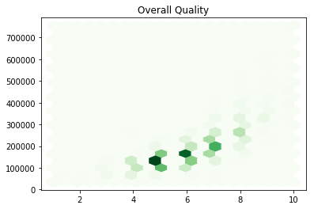

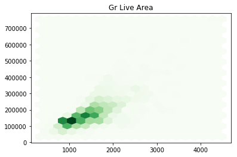

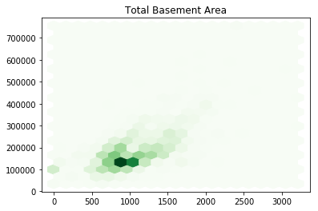

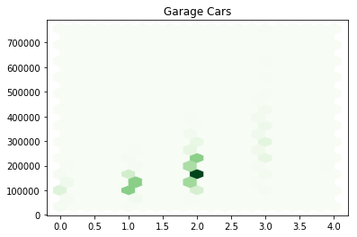

```python
plt.hexbin(train['OverallQual'],train['SalePrice'], gridsize = 20, cmap ='Greens')
plt.title('Overall Quality')
plt.show()

plt.hexbin(train['GrLivArea'],train['SalePrice'], gridsize = 20, cmap ='Greens')
plt.title('Gr Live Area')

plt.show()

plt.hexbin(train['TotalBsmtSF'],train['SalePrice'], gridsize = 20, cmap ='Greens')
plt.title('Total Basement Area')
plt.show()

plt.hexbin(train['GarageCars'],train['SalePrice'], gridsize = 20, cmap ='Greens')
plt.title('Garage Cars')
plt.show()
```

## 7

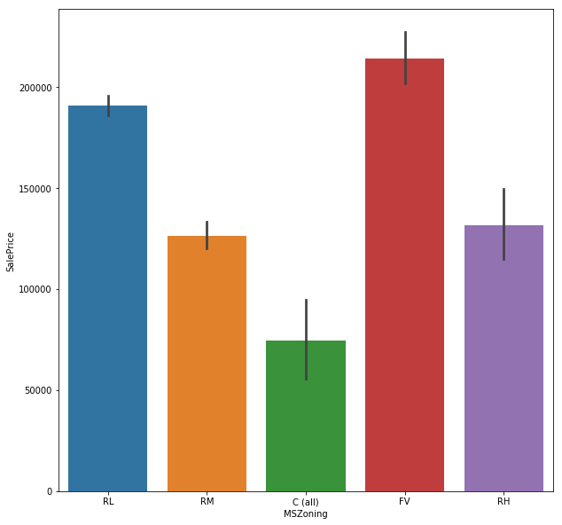

```python
plt.figure(figsize = (10,10))
sns.barplot(x='MSZoning',y='SalePrice',data=train)
plt.show()
```

plt.figure(figsize = (10,10)) sns.barplot(x='CentralAir',y='SalePrice',data=train) plt.show()

# train["MSZoning"].value_counts()

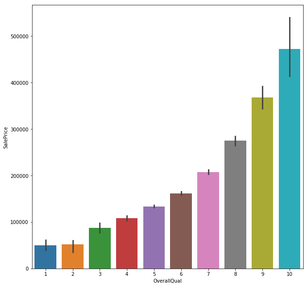

```python
plt.figure(figsize = (10,10))
sns.barplot(x='OverallQual',y='SalePrice',data=train)
plt.show()
```

plt.figure(figsize = (12,10)) sns.barplot(x='Exterior1st',y='SalePrice',data=train) plt.show() sns.barplot(x='Exterior2nd',y='SalePrice',data=train) plt.show()

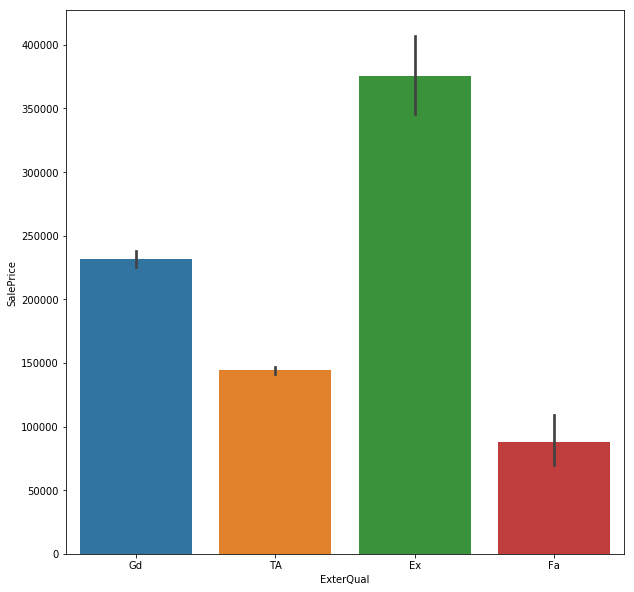

```python
plt.figure(figsize = (10,10))
sns.barplot(x='ExterQual',y='SalePrice',data=train)
```

## Phase 1

## 1

## داده های گمشده

### بیشترین فراوانی یا( مقدار 0 / ثابت)

مزیت : برای داده های دسته ای کار میکند. معایب : وابستگی بین ویژگی ها را factor نمی کند- میتواند باعث ایجاد bias در داده شود. ### KNN به داده ی جدید بر حسب اینکه چقدر به داده ها در مجموعه train شباهت دارد مقداری نسبت داده می شود.k همسایه نزدیک به داده با مقدار گمشده را پیدا کرده و براساس مقدار هایی که وجود دارند(گم نشده اند)مقداری را به آن نسبت می دهیم. مزیت :می تواند نسبت به میانگین یا بیشترین فراوانی دقیق تر باشد.(به دیتاست بستگی دارد) معایب : محاسبات زیادی دارد و به داده های خارج از محدوده (outlier)ها حساس است. ### میانگین میانگین به نویز حساس است. نمی توان در داده های categorical از آن استفاده کرد.

```python
def delMisVal():
    train.drop("PoolQC",axis = 1,inplace = True)
    train.drop("Fence",axis = 1,inplace = True)
    train.drop("MiscFeature",axis = 1,inplace = True)
    train.drop("Alley",axis = 1,inplace = True)
    train.drop("FireplaceQu", axis = 1,inplace = True)

    train.drop("BsmtQual",axis = 1,inplace = True)
    train.drop("BsmtCond",axis = 1,inplace = True)
    train.drop("BsmtExposure",axis = 1,inplace = True)
    train.drop("BsmtFinType1",axis = 1,inplace = True)
    train.drop("BsmtFinType2",axis = 1,inplace = True)

    train.drop("GarageType",axis = 1,inplace = True)
    train.drop("GarageFinish",axis = 1,inplace = True)
    train.drop("GarageQual",axis = 1,inplace = True)
    train.drop("GarageCond",axis = 1,inplace = True)
    train.drop(train.loc[train['Electrical'].isnull()].index , inplace = True)

def fillMisVal():
    train["BsmtQual"] = train["BsmtQual"].fillna("None")
    train["BsmtCond"] = train["BsmtCond"].fillna("None")
    train["BsmtExposure"] = train["BsmtExposure"].fillna("None")
    train["BsmtFinType1"] = train["BsmtFinType1"].fillna("None")
    train["BsmtFinType2"] = train["BsmtFinType2"].fillna("None")

    train["FireplaceQu"] = train["FireplaceQu"].fillna("None")
    train["GarageType"] = train["GarageType"].fillna("None")
    train["GarageFinish"] = train["GarageFinish"].fillna("None")
    train["GarageQual"] = train["GarageQual"].fillna("None")
    train["GarageCond"] = train["GarageCond"].fillna("None")

    train["PoolQC"] = train["PoolQC"].fillna("None")
    train["Alley"] = train["Alley"].fillna("None")
    train["Fence"] = train["Fence"].fillna("None")

    train["MiscFeature"] = train["MiscFeature"].fillna("None")
    trian["Electrical"].fillna(train["Electrical"].median(),inplace = True)



train['LotFrontage'].fillna(train['LotFrontage'].median(),inplace = True)
train['GarageYrBlt'].fillna(train['GarageYrBlt'].median(),inplace = True)
train['MasVnrArea'].fillna(train['MasVnrArea'].median(), inplace = True)
```

```python
def preprocess(misValfunc,delCol):
    if(misValfunc is "dropCol"):
        delMisVal()
    elif(misValfunc is "fillMisVal"):
        fillMisVal()
    if(delCol):
        delCols()
```

## 2

PoolQC 99.520548 MiscFeature 96.301370 Alley 93.767123 Fence 80.753425 FireplaceQu 47.260274 در صورتی که ستون ها حاوی اطلاعات مفیدی باشند نباید آنها را حذف کرد.در توضیحات برای تعداد زیادی از مقادیر گمشده آمده است که مقدار Nan به معنای عدم وجود آن ویژگی در خانه است بنابراین این مقادیر گم نشده اند و بهتر است آنها را نگه داشت.

## 3

## نرمال / استاندارد سازی

هنگامیکه ویژگی ها واحد های متفاوتی داشته باشند. متغیرهایی که در مقیاس های متفاوتی اندازه گیری شده اند ممکن است باعث ایجاد bias شود.روش های معمول استاندارد سازی دامنه و یا تنوع داده ها را برابر می کند.نرمال سازی هنگامیکه الگوریتم فرضی بر توزیع دیتا ندارد مناسب است. از آنجاییکه داده های رنج متفاوتی دارند از استفاده میکنیم.

## 4

## داده های دسته ای

داده های دسته ای چند نوع هستند : binary:تنها دو مقدار دارند مثل درست/غلط و ... Ordinal : دارای ترتیب خاصی هستند.مقطع تحصیلی Nominal ترتیب مشخصی ندارند.مثل شهرها Label Encoding or Ordinal Encoding هنگامی که داده های دسته ای Ordinal هستند از این استفاده می کنیم.حفظ کردن ترتیب اهمیت دارد.هر برچسب به یک عدد تبدیل می شود. One Hot Encoding زمانی کاربرد دارد که داده ها nominal هستند.برای هر از داده ی دسته ای یک متغیر جدید (dummy)می سازیم.اگر 0 باشد به معنای عدم حضور متغیر و 1 به معنای وجود متغیر است. Target encoding میانگین متغیر هدف را برای هر دسته محاسبه می کنیم و آن را با میانگین جایگزین میکنیم.اگر ستون هدف categorical باشد.posterior با هر دسته جایگزین می شود. تنها برای train data از taget encoding استفاده میکنیم. ممکن است باعث overfitting یا leakage شود https://www.analyticsvidhya.com/blog/2020/08/types-of-categorical-data-encoding/

import category_encoders as ce

encoder=ce.TargetEncoder()

train2 = encoder.fit_transform(train.drop("SalePrice",axis = 1),train["SalePrice"])

## 5

تعدادی از ویژگی ها را به دلیل شبیه بودن به یکدیگر وبعضی را به خاط عدم وجود همبستگی با قیمت خانه(ضریب همبستگی نزدیک به صفر) حذف کردیم. با توجه به Heatmap دو ویژگی GarageArea , GarageCars ضریب همبستگی 0.88 را دارند (با افزایش مساحت تعداد ماشین هایی که در گاراژ جا می گیرند نیز افزایش می یابد)یکی از آنها را حذف می کنیم(GarageArea) همچنین GarageYrBlt نیز ضریب همبستگی 0.83 را با YearBuilt دارد(می توان تصور کرد همان سالی که خانه ساخته شده گاراژ نیز ساخته شده) MiscVal :ارزش ویژگی های متفرقه با ضریب همبستگی 0.02 را نیز حذف می کنیم. BsmHalfBath: ضریب همبستگی 0.01 با قیمت خانه دارد. Id نیز با ضریب همبستگی 0.02 قبلا حذف شده.

```python
def delCols():
    train.drop("MiscVal",axis = 1,inplace = True)
    train.drop("BsmtHalfBath",axis = 1,inplace = True)
    train.drop("GarageArea",axis = 1,inplace = True)
```

```python
del_cols = True
misValfunc = "dropMisVal"
preprocess(misValfunc,del_cols)
```

```python
train2 = pd.get_dummies(train)
```

## 6

split ratio به مقدار زیادی به type مدلی که می سازیم و دیتاست مرتبط است.اگر مدل hyperparameter زیادی داشت که باید tune شود مقدار بیشتری از داده را برای train انتخاب می کنیم. مقدار معمول حدود 70 -30 و یا 80-20 است. K-Fold Cross Validation داده به K زیر مجموعه تقسیم میشود.هر بار یکی از k زیرمجموعه برای validation و k-1 زیرمجموعه دیگر در کنار هم قرار گرفته و training set را تشکیل می دهند. تخمین خطا میانگینی از K آزمون است .k=5 و یا k=10 معمولا ترجیح داده می شود. Leave-P-Out Cross Validation p تا از observation ها را به عنوان validation set انتخاب کرده و باقی را به عنوان train set در نظر میگیریم.این کار برای تمام حالات انتخاب P تا observation انجام می دهیم.که زمان محاسبه خیلی زیادی دارد. در p = 1 Leave-one-out cross-validation هر دیتاست شامل یک سری random effect است.نمی دانیم در دیتاست کدام داده ها رندوم و کدام یم الگوی واقعی هستند .همچنین توزیع یک کلاس باید حفظ شود.به همین دلیل تقسیم داده ها بهتر است به صورت تصادفی صورت گیرد. https://towardsdatascience.com/train-test-split-c3eed34f763b https://towardsdatascience.com/cross-validation-in-machine-learning-72924a69872f

## Phase 2

```python
df = train2.copy()

#p = 0.7
#df_train = train2.iloc[:int(p * train2.shape[0]),:]
#df_test = train2.iloc[int(p * train2.shape[0]):,:]
#X_train = df_train.drop("SalePrice",axis = 1)
#X_test = df_test.drop("SalePrice",axis=1)
#y_test = df_test["SalePrice"]
#y_train = df_train["SalePrice"]

features = df.drop("SalePrice",axis=1)
X_train, X_test, y_train, y_test = train_test_split(features,train2["SalePrice"], test_size=0.2)
```

```python
lr = LinearRegression()
lr.fit(X_train, y_train)

y_test_pred = lr.predict(X_test)
y_train_pred = lr.predict(X_train)

rmse_te = mean_squared_error(y_test, y_test_pred, squared = False)
rmse_tr = mean_squared_error(y_train,y_train_pred,squared = False)

mae_te = mean_absolute_error(y_test, y_test_pred)
mae_tr = mean_absolute_error(y_train, y_train_pred)

print("MAE:")
print("test",mae_te,"train",mae_tr)
print("RMSE:")
print("test",rmse_te,"train",rmse_tr)
```

```
MAE:
test 12237.283494028494 train 8631.640336312994
RMSE:
test 19460.800122365777 train 13326.938219994408
```

```python
dt = DecisionTreeRegressor(max_depth = 6)

dt.fit(X_train,y_train)

y_test_pred = dt.predict(X_test)
y_train_pred = dt.predict(X_train)

parameters = {'max_depth': [2,4,6,8,10,12]}

gs_cv = GridSearchCV(DecisionTreeRegressor(random_state=42), parameters, verbose=1, cv=3,scoring = 'neg_mean_absolute_error')
gs_cv.fit(X_train, y_train)

print(gs_cv.best_params_)
print(gs_cv.best_score_)
print(gs_cv.best_estimator_)

rmse_te = mean_squared_error(y_test, y_test_pred, squared=False)
rmse_tr = mean_squared_error(y_train, y_train_pred, squared=False)
mae_te = mean_absolute_error(y_test, y_test_pred)
mae_tr = mean_absolute_error(y_train, y_train_pred)

print("MAE:")
print("test",mae_te,"train",mae_tr)
print("RMSE")
print("test",rmse_te,"train",rmse_tr)
```

```
Fitting 3 folds for each of 6 candidates, totalling 18 fits
```

```
[Parallel(n_jobs=1)]: Using backend SequentialBackend with 1 concurrent workers.
```

```
{'max_depth': 12}
-1569.288650959814
DecisionTreeRegressor(ccp_alpha=0.0, criterion='mse', max_depth=12,
                      max_features=None, max_leaf_nodes=None,
                      min_impurity_decrease=0.0, min_impurity_split=None,
                      min_samples_leaf=1, min_samples_split=2,
                      min_weight_fraction_leaf=0.0, presort='deprecated',
                      random_state=42, splitter='best')
MAE:
test 1777.554644456238 train 1349.7777163689404
RMSE
test 3215.284853545516 train 1784.6500855124273
```

```
[Parallel(n_jobs=1)]: Done  18 out of  18 | elapsed:    0.7s finished
```

```python
#standard
ss = StandardScaler()
Xtrain = ss.fit_transform(X_train)
Xtest = ss.transform(X_test)
```

```python
grid_params = {'n_neighbors':[5,11,19,25],'weights':['uniform','distance']}
gs = GridSearchCV(KNeighborsRegressor(),grid_params,verbose = 1,cv = 3)
gs_results = gs.fit(Xtrain,y_train)
print(gs_results.best_score_ , gs_results.best_estimator_)
gs_results.best_params_
```

```
[Parallel(n_jobs=1)]: Using backend SequentialBackend with 1 concurrent workers.
```

```
Fitting 3 folds for each of 8 candidates, totalling 24 fits
0.7534548614125604 KNeighborsRegressor(algorithm='auto', leaf_size=30, metric='minkowski',
                    metric_params=None, n_jobs=None, n_neighbors=11, p=2,
                    weights='distance')
```

```
[Parallel(n_jobs=1)]: Done  24 out of  24 | elapsed:   10.5s finished
```

```
{'n_neighbors': 11, 'weights': 'distance'}
```

```python
knn = KNeighborsRegressor(n_neighbors = 5)
knn.fit(Xtrain, y_train)

y_train_pred = knn.predict(Xtrain)
y_test_pred = knn.predict(Xtest)

rmse_te = mean_squared_error(y_test, y_test_pred,  squared=False)
rmse_tr = mean_squared_error(y_train, y_train_pred, squared=False)

mae_te = mean_absolute_error(y_test, y_test_pred)
mae_tr = mean_absolute_error(y_train,y_train_pred)

print("MAE")
print("test",mae_te,"train",mae_tr)
print("RMSE")
print("test",rmse_te,"train",rmse_tr)
```

```
MAE
test 24920.97808219178 train 20489.41972555746
RMSE
test 39894.67952409022 train 32196.248378394324
```

## 3

overfitting حالتی است که داده بر روی trian خیلی خوب عمل کند وحتی نویز ها را نیز مدل می کند(train را خیلی خوب یاد می گیرد) ولی قابلیت generalization را از دست دهد بر روی تست خوب عمل نکند . underfitting زمانی است که داده آموزشی را به اندازه کافی یاد نگرفته و قابلیت generalization را نیز از دست می دهد.و ممکن است روند غالب را نیز تشخیص ندهد و انعطاف ندارد.در این مورد بر روی train نیز وب عمل نمی کند. برای می توان ار تابع learning_curves استفاده نمود

```python
parameters ={'max_depth': range(3,7),'n_estimators': [5,10,20,40,60],'max_features': ['auto', 'sqrt', 'log2']}
gsc = GridSearchCV(RandomForestRegressor(),parameters, cv=5, verbose=0,n_jobs=-1,scoring = 'neg_root_mean_squared_error')
grid_result = gsc.fit(X_train, y_train)
best_params = grid_result.best_params_
print(best_params)
```

[output not shown]

```python
rfr = RandomForestRegressor(max_depth = 6 , max_features = 'auto',n_estimators = 40)
rfr.fit(X_train, y_train)

y_train_pred = rfr.predict(X_train)
y_test_pred = rfr.predict(X_test)

rmse_te = mean_squared_error(y_test, y_test_pred,  squared=False)
rmse_tr = mean_squared_error(y_train, y_train_pred, squared=False)
mae_te = mean_absolute_error(y_test, y_test_pred)
mae_tr = mean_absolute_error(y_train,y_train_pred)

print("MAE")
print("test",mae_te,"train",mae_tr)

print("RMSE")
print("test",rmse_te,"train",rmse_tr)
```

```
MAE
test 1044.0553564466309 train 660.644152984707
RMSE
test 4025.203186038494 train 2587.7376146541687
```

```python
vreg = VotingRegressor([('knn',knn), ('Dtree', dt), ('lr',lr)])
vreg.fit(X_train,y_train)

y_train_pred = vreg.predict(X_train)
y_test_pred = vreg.predict(X_test)

rmse_te = mean_squared_error(y_test, y_test_pred,  squared=False)
rmse_tr = mean_squared_error(y_train, y_train_pred, squared=False)
mae_te = mean_absolute_error(y_test, y_test_pred)
mae_tr = mean_absolute_error(y_train,y_train_pred)

print("MAE")
print("test",mae_te,"train",mae_tr)

print("RMSE")
print("test",rmse_te,"train",rmse_tr)
```

```
MAE
test 11504.769140546536 train 8848.759744334018
RMSE
test 18909.2637869564 train 14865.773507303305
```

نسبت به knn وlinear regression در اکثر موارد بهتر عمل می کند و واریانس کمتری دارد.اما نسبت به Decision Tree بدتر عمل میکند. (چون درخت تصمیم خیلی بهتر نسبت به دو الگوربتم دیگر عمل می کند هنگام میانگین گرفتن بین خروجی مدل ها جواب voting regression نسبت به knn بهتر می شود اما در نهایت در برابر درخت تصمیم شکست میخورد)